# Análisis Bivariado: Estadísticas de Jugadores de la NBA

11 relaciones entre variables clave del dataset `nbaFINAL.csv` (temporadas 1982-2022), con control por posición, agrupaciones por rango y variables derivadas

Análisis exploratorio de datos (EDA)

18 de septiembre de 2026

# 1 Análisis bivariado

El análisis univariado permitió caracterizar cada variable por separado y dejó tres resultados de partida: un panel de **10 variables clave**, cada una representando una dimensión distinta del rendimiento sin que ninguna pareja entre ellas supere una correlación absoluta de 0.8; una **matriz de correlación completa**, que distinguió identidades algebraicas, relaciones mecánicas de volumen, mediciones redundantes y hallazgos genuinamente empíricos; y la advertencia de que variables como `porc_intentos_triple` o `edad` mezclan información que solo se interpreta correctamente al examinar subgrupos o la evolución temporal, y no un único coeficiente.

## 1.1 Relaciones analizadas

```r
relaciones <- tribble(
  ~Relacion, ~Variables, ~Tecnica, ~Pregunta,
  "1. Uso ofensivo vs. eficiencia de tiro", "porc_uso_jugador vs. porc_tiro_verdadero", "Dispersión + recta de ajuste + cuadrantes", "¿Tirar más cuesta eficiencia, o hay estrellas que hacen ambas cosas?",
  "2. Rendimiento vs. edad", "edad vs. indice_eficiencia, porc_tiro_verdadero, minutos_pp", "Boxplots por grupo de edad", "¿A qué edad rinde más un jugador promedio, y por qué un coeficiente sería engañoso?",
  "3. Asistencias vs. pérdidas, por posición", "asistencias_pp vs. perdidas_pp, agrupado por posicion", "Boxplots por posición + correlación dentro de cada grupo", "¿El manejo de balón cuesta pérdidas dentro del mismo rol, o solo entre roles distintos?",
  "4. % de intentos de triple vs. temporada", "porc_intentos_triple vs. temporada", "Boxplots por era (grupos de temporadas)", "¿Cuándo y qué tan rápido cambió el estilo de juego de la NBA?",
  "5. Rebote vs. creación de juego", "porc_rebotes_tot_disp vs. porc_asistencias_equipo", "Dispersión coloreada por posición", "¿Rebotear y asistir son roles opuestos, y quién rompe esa regla?",
  "6. Protagonismo vs. producción", "porc_uso_jugador vs. puntos_pp", "Dispersión + recta de ajuste + cuadrante bajo-alto", "¿Se puede anotar mucho sin ser el protagonista ofensivo del equipo?",
  "7. Oportunidad vs. valor total", "minutos_totales vs. valor_sobre_reemplazo", "Boxplots por decil de minutos", "¿El valor crece proporcional a los minutos, o se acelera?",
  "8. Manejo de balón vs. pérdidas normalizadas", "porc_uso_jugador vs. porc_perdidas_jugada", "Dispersión + recta de ajuste", "¿Más protagonismo implica más riesgo de pérdida por jugada?",
  "9. Contexto de equipo vs. impacto defensivo", "porc_victorias_equipo vs. masmenos_defensivo", "Dispersión + recta de ajuste + cuadrante", "¿Los buenos defensores solo aparecen en equipos ganadores?",
  "10. Experiencia vs. eficiencia, por edad de entrada", "experiencia (derivada) vs. indice_eficiencia, por edad_entrada (derivada)", "Boxplots agrupados por bloque de experiencia y edad de entrada", "¿Un novato que entra joven rinde distinto, a igual experiencia, que uno que entra mayor?",
  "11. Anotación vs. creación de juego, por posición", "puntos_pp vs. asistencias_pp, coloreado por posicion", "Dispersión coloreada por posición + recta de ajuste global", "¿Anotar mucho implica asistir poco, o ese supuesto compromiso no se cumple?"
)

relaciones %>%
  kable(
    col.names = c("Relación", "Variables", "Técnica", "Pregunta que responde"),
    caption = "Las 11 relaciones bivariadas seleccionadas para esta sección"
  ) %>%
  kable_styling(
    bootstrap_options = c("striped", "hover", "condensed"),
    font_size = 12
  ) %>%
  column_spec(1, bold = TRUE, width = "20%") %>%
  column_spec(2, monospace = TRUE, width = "22%")
```

Las 11 relaciones bivariadas seleccionadas para esta sección

Relación

Variables

Técnica

Pregunta que responde

1. Uso ofensivo vs. eficiencia de tiro

porc_uso_jugador vs. porc_tiro_verdadero

Dispersión + recta de ajuste + cuadrantes

¿Tirar más cuesta eficiencia, o hay estrellas que hacen ambas cosas?

2. Rendimiento vs. edad

edad vs. indice_eficiencia, porc_tiro_verdadero, minutos_pp

Boxplots por grupo de edad

¿A qué edad rinde más un jugador promedio, y por qué un coeficiente sería engañoso?

3. Asistencias vs. pérdidas, por posición

asistencias_pp vs. perdidas_pp, agrupado por posicion

Boxplots por posición + correlación dentro de cada grupo

¿El manejo de balón cuesta pérdidas dentro del mismo rol, o solo entre roles distintos?

4. % de intentos de triple vs. temporada

porc_intentos_triple vs. temporada

Boxplots por era (grupos de temporadas)

¿Cuándo y qué tan rápido cambió el estilo de juego de la NBA?

5. Rebote vs. creación de juego

porc_rebotes_tot_disp vs. porc_asistencias_equipo

Dispersión coloreada por posición

¿Rebotear y asistir son roles opuestos, y quién rompe esa regla?

6. Protagonismo vs. producción

porc_uso_jugador vs. puntos_pp

Dispersión + recta de ajuste + cuadrante bajo-alto

¿Se puede anotar mucho sin ser el protagonista ofensivo del equipo?

7. Oportunidad vs. valor total

minutos_totales vs. valor_sobre_reemplazo

Boxplots por decil de minutos

¿El valor crece proporcional a los minutos, o se acelera?

8. Manejo de balón vs. pérdidas normalizadas

porc_uso_jugador vs. porc_perdidas_jugada

Dispersión + recta de ajuste

¿Más protagonismo implica más riesgo de pérdida por jugada?

9. Contexto de equipo vs. impacto defensivo

porc_victorias_equipo vs. masmenos_defensivo

Dispersión + recta de ajuste + cuadrante

¿Los buenos defensores solo aparecen en equipos ganadores?

10. Experiencia vs. eficiencia, por edad de entrada

experiencia (derivada) vs. indice_eficiencia, por edad_entrada (derivada)

Boxplots agrupados por bloque de experiencia y edad de entrada

¿Un novato que entra joven rinde distinto, a igual experiencia, que uno que entra mayor?

11. Anotación vs. creación de juego, por posición

puntos_pp vs. asistencias_pp, coloreado por posicion

Dispersión coloreada por posición + recta de ajuste global

¿Anotar mucho implica asistir poco, o ese supuesto compromiso no se cumple?

De las propuestas iniciales se descartaron cuatro por falta de datos en `nbaFINAL.csv` (estatura, salario, indicador de fase playoffs/temporada regular e indicador de franquicia campeona): ninguna de esas columnas existe en el archivo, y construirlas exigiría fusionar fuentes externas fuera del alcance de este dataset.

## 1.2 1. Uso ofensivo (USG%) vs. eficiencia de tiro (TS%)

La variable `porc_uso_jugador`, conocida en la analítica de baloncesto como Porcentaje de Uso (*Usage Percentage*, USG%), estima qué proporción de las jugadas del equipo termina siendo decidida por ese jugador —con un tiro, una falta recibida que lo envía a la línea de libres, o una pérdida— mientras está en cancha. La variable `porc_tiro_verdadero`, o Porcentaje de Tiro Verdadero (*True Shooting Percentage*, TS%), mide qué tan eficiente es anotando, combinando en un solo valor los tiros de dos puntos, los triples y los tiros libres. La pregunta que se examina no es cuál jugador anota más, sino si tomar un mayor volumen de tiro implica necesariamente una pérdida de eficiencia.

```r
r_uso_ts <- cor(df$porc_uso_jugador, df$porc_tiro_verdadero, use = "pairwise.complete.obs")
med_usg  <- median(df$porc_uso_jugador, na.rm = TRUE)
med_ts   <- median(df$porc_tiro_verdadero, na.rm = TRUE)
```

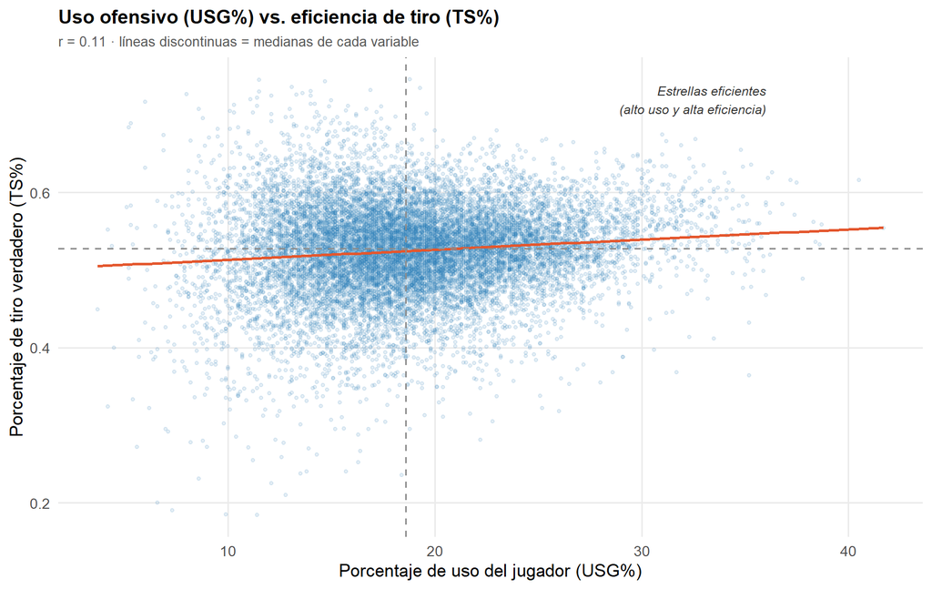

```r
ggplot(df, aes(x = porc_uso_jugador, y = porc_tiro_verdadero)) +
  geom_point(alpha = 0.12, color = col_punto, size = 1, na.rm = TRUE) +
  geom_smooth(method = "lm", se = FALSE, color = col_ajuste, linewidth = 1, na.rm = TRUE) +
  geom_hline(yintercept = med_ts, linetype = "dashed", color = "grey55") +
  geom_vline(xintercept = med_usg, linetype = "dashed", color = "grey55") +
  annotate("text", x = 36, y = 0.72,
           label = "Estrellas eficientes\n(alto uso y alta eficiencia)",
           hjust = 1, size = 3.3, fontface = "italic", color = "grey20") +
  labs(
    title = "Uso ofensivo (USG%) vs. eficiencia de tiro (TS%)",
    subtitle = paste0("r = ", round(r_uso_ts, 3),
                       " · líneas discontinuas = medianas de cada variable"),
    x = "Porcentaje de uso del jugador (USG%)",
    y = "Porcentaje de tiro verdadero (TS%)"
  ) +
  tema_biv
```

```r
df %>%
  filter(porc_uso_jugador > med_usg, porc_tiro_verdadero > med_ts) %>%
  slice_max(valor_sobre_reemplazo, n = 5) %>%
  select(jugador, temporada, porc_uso_jugador, porc_tiro_verdadero, valor_sobre_reemplazo) %>%
  kable(
    digits = c(0, 0, 1, 3, 1),
    col.names = c("Jugador", "Temporada", "USG% (uso ofensivo)", "TS% (eficiencia de tiro)", "VORP (valor total aportado)"),
    caption = "Rompen el patrón: alto uso Y alta eficiencia a la vez"
  ) %>%
  kable_styling(bootstrap_options = c("striped", "condensed"), full_width = FALSE)
```

Rompen el patrón: alto uso Y alta eficiencia a la vez

| Jugador | Temporada | USG% (uso ofensivo) | TS% (eficiencia de tiro) | VORP (valor total aportado) |
| --- | --- | --- | --- | --- |
| Michael Jordan | 1988 | 34.1 | 0.603 | 12.5 |
| LeBron James | 2009 | 33.8 | 0.591 | 11.8 |
| Michael Jordan | 1989 | 32.1 | 0.614 | 11.4 |
| David Robinson | 1994 | 32.0 | 0.577 | 11.4 |
| Michael Jordan | 1991 | 32.9 | 0.605 | 10.8 |

```r
df %>%
  filter(
    porc_uso_jugador > quantile(porc_uso_jugador, 0.85, na.rm = TRUE),
    porc_tiro_verdadero < quantile(porc_tiro_verdadero, 0.25, na.rm = TRUE)
  ) %>%
  slice_max(porc_uso_jugador, n = 5) %>%
  select(jugador, temporada, porc_uso_jugador, porc_tiro_verdadero, puntos_pp) %>%
  kable(
    digits = c(0, 0, 1, 3, 1),
    col.names = c("Jugador", "Temporada", "USG% (uso ofensivo)", "TS% (eficiencia de tiro)", "Puntos por partido"),
    caption = "Alto uso con baja eficiencia: anotan por volumen, no por conversión"
  ) %>%
  kable_styling(bootstrap_options = c("striped", "condensed"), full_width = FALSE)
```

Alto uso con baja eficiencia: anotan por volumen, no por conversión

| Jugador | Temporada | USG% (uso ofensivo) | TS% (eficiencia de tiro) | Puntos por partido |
| --- | --- | --- | --- | --- |
| Allen Iverson | 2002 | 37.8 | 0.489 | 31.4 |
| Michael Jordan | 2002 | 36.0 | 0.468 | 22.9 |
| Allen Iverson | 2004 | 35.3 | 0.478 | 26.4 |
| Oliver Robinson | 1983 | 35.2 | 0.432 | 2.9 |
| John Schweitz | 1985 | 35.2 | 0.364 | 3.0 |

**Interpretación:** la correlación entre ambas variables es prácticamente nula (r = 0.11), lo que es consistente con lo señalado en el análisis univariado, donde `porc_tiro_verdadero` se identificó como una variable que aporta información independiente del uso (r = 0.11 con `porc_uso_jugador`). La nube de puntos no tiene forma de elipse inclinada, sino una mancha ancha sin pendiente definida, lo que confirma que, en promedio, usar más el balón no implica ni mejor ni peor eficiencia. El promedio, sin embargo, no es lo más informativo de esta relación: son los extremos los que distinguen tipos de jugador. El cuadrante superior derecho —USG% y TS% simultáneamente altos— lo ocupan Michael Jordan, LeBron James y David Robinson en algunas de sus mejores temporadas, mostrando que llevar el peso ofensivo del equipo y anotar con eficiencia de élite al mismo tiempo es la firma estadística de una superestrella. En el extremo opuesto, jugadores como Allen Iverson o un Michael Jordan de 38 años en los Washington Wizards mantienen un USG% alto sin la eficiencia que lo acompañaba en sus mejores años, lo que indica que siguen concentrando el balón por rol o por falta de alternativas en el equipo, más que por su rendimiento actual. Para un cuerpo técnico, distinguir entre ambos grupos equivale a decidir a quién conviene seguir dándole el balón y a quién ya no.

## 1.3 2. Rendimiento vs. edad, como curva y no como correlación

Esta relación examina la edad del jugador (`edad`) frente a tres indicadores de rendimiento: el Índice de Eficiencia del Jugador o PER (`indice_eficiencia`), el Porcentaje de Tiro Verdadero (`porc_tiro_verdadero`, TS%) y los minutos jugados por partido (`minutos_pp`). El PER resume, por cada minuto en cancha, la producción positiva de un jugador (puntos, rebotes, asistencias, robos, tapones) menos la negativa (tiros fallados, pérdidas, faltas), calibrado de forma que el promedio de la liga en cualquier temporada sea igual a 15; a diferencia de TS% y de los minutos, el PER no formó parte del panel de variables clave del análisis univariado, por lo que se introduce en esta sección. Ninguna de las tres métricas mantiene una relación lineal con la edad: cada una aumenta durante la juventud del jugador, alcanza un máximo y decae después. Reportar solo un coeficiente de correlación describiría esta relación de forma incompleta, porque un valor cercano a cero puede ocultar una curva real en lugar de la ausencia de relación.

```r
r_edad_per <- cor(df$edad, df$indice_eficiencia, use = "pairwise.complete.obs")

resumen_edad <- df %>%
  group_by(edad) %>%
  summarise(
    PER = mean(indice_eficiencia, na.rm = TRUE),
    TS = mean(porc_tiro_verdadero, na.rm = TRUE),
    Minutos = mean(minutos_pp, na.rm = TRUE),
    n = n(),
    .groups = "drop"
  )

edad_pico_per <- resumen_edad$edad[which.max(resumen_edad$PER)]

# Agrupar la edad en rangos para poder resumir la curva con boxplots
df <- df %>%
  mutate(
    grupo_edad = cut(
      edad,
      breaks = c(17, 21, 24, 27, 30, 33, 50),
      labels = c("18-21", "22-24", "25-27", "28-30", "31-33", "34+"),
      right = TRUE
    )
  )
```

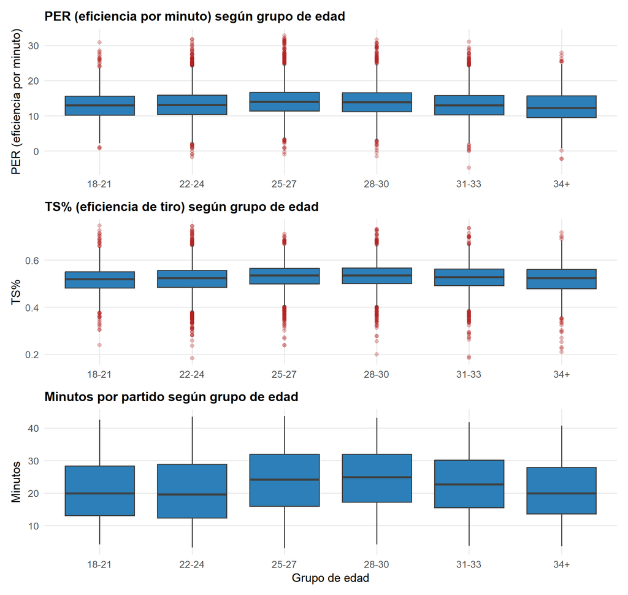

```r
p_per <- ggplot(df, aes(x = grupo_edad, y = indice_eficiencia)) +
  geom_boxplot(fill = col_punto, color = "grey25", outlier.color = col_outlier,
               outlier.alpha = 0.3, na.rm = TRUE) +
  labs(title = "PER (eficiencia por minuto) según grupo de edad", x = NULL, y = "PER (eficiencia por minuto)") +
  tema_biv

p_ts <- ggplot(df, aes(x = grupo_edad, y = porc_tiro_verdadero)) +
  geom_boxplot(fill = col_punto, color = "grey25", outlier.color = col_outlier,
               outlier.alpha = 0.3, na.rm = TRUE) +
  labs(title = "TS% (eficiencia de tiro) según grupo de edad", x = NULL, y = "TS%") +
  tema_biv

p_min <- ggplot(df, aes(x = grupo_edad, y = minutos_pp)) +
  geom_boxplot(fill = col_punto, color = "grey25", outlier.color = col_outlier,
               outlier.alpha = 0.3, na.rm = TRUE) +
  labs(title = "Minutos por partido según grupo de edad", x = "Grupo de edad", y = "Minutos") +
  tema_biv

p_per / p_ts / p_min
```

```r
resumen_edad %>%
  filter(edad >= 19, edad <= 38) %>%
  select(edad, PER, TS, Minutos, n) %>%
  kable(
    digits = c(0, 1, 3, 1, 0),
    col.names = c("Edad", "PER promedio (eficiencia por minuto)", "TS% promedio (eficiencia de tiro)", "Minutos/partido promedio", "Cantidad de temporadas-jugador (n)"),
    caption = "Promedio de tres métricas de rendimiento, por edad"
  ) %>%
  kable_styling(bootstrap_options = c("striped", "condensed"), full_width = FALSE) %>%
  scroll_box(height = "300px")
```

Promedio de tres métricas de rendimiento, por edad

| Edad | PER promedio (eficiencia por minuto) | TS% promedio (eficiencia de tiro) | Minutos/partido promedio | Cantidad de temporadas-jugador (n) |
| --- | --- | --- | --- | --- |
| 19 | 12.1 | 0.506 | 19.9 | 130 |
| 20 | 12.8 | 0.514 | 20.3 | 348 |
| 21 | 13.5 | 0.521 | 21.3 | 555 |
| 22 | 13.1 | 0.516 | 19.9 | 1092 |
| 23 | 13.1 | 0.517 | 20.3 | 1441 |
| 24 | 13.5 | 0.524 | 21.6 | 1444 |
| 25 | 14.1 | 0.530 | 23.1 | 1316 |
| 26 | 14.3 | 0.531 | 23.8 | 1201 |
| 27 | 14.3 | 0.532 | 24.5 | 1116 |
| 28 | 14.3 | 0.534 | 24.7 | 1004 |
| 29 | 14.0 | 0.533 | 24.1 | 936 |
| 30 | 13.8 | 0.529 | 24.0 | 818 |
| 31 | 13.3 | 0.523 | 23.1 | 690 |
| 32 | 13.4 | 0.528 | 22.5 | 562 |
| 33 | 13.0 | 0.520 | 22.1 | 452 |
| 34 | 12.8 | 0.521 | 21.6 | 326 |
| 35 | 13.0 | 0.523 | 21.5 | 233 |
| 36 | 12.9 | 0.527 | 20.8 | 170 |
| 37 | 12.4 | 0.509 | 19.3 | 103 |
| 38 | 12.0 | 0.493 | 18.0 | 68 |

**Interpretación:** el coeficiente de correlación lineal entre `edad` e `indice_eficiencia` es r = -0.006, un valor esencialmente nulo. Sin embargo, los boxplots agrupados por rango de edad muestran que la distribución del PER no es constante: asciende del grupo 18-21 al grupo 25-27, donde se ubica el máximo (con el grupo 28-30 muy cercano), y desciende de forma sostenida hasta el grupo de 34 años o más. El mismo patrón de ascenso, pico y descenso aparece en TS% y en los minutos por partido. La correlación lineal no detecta esta forma porque mide asociación en una sola dirección: como la primera mitad de la relación es creciente y la segunda decreciente, ambas tendencias se cancelan en el coeficiente agregado, y solo se hacen visibles al segmentar por grupos de edad. Esta curva corresponde al ciclo de desarrollo físico y declive atlético típico de un deportista profesional, y tiene implicaciones directas para la gestión de un equipo: explica por qué los contratos de mayor cuantía en la NBA se concentran en jugadores de 24 a 29 años —el rango de mejor rendimiento esperado— y por qué extender un contrato largo a un jugador de 33 años implica, en términos estadísticos, apostar contra la tendencia más consistente de todo el conjunto de datos. De igual forma, dado que el PER promedio todavía está en ascenso antes de los 22 años, evaluar a un jugador joven únicamente por su producción en sus primeras temporadas subestima de forma sistemática su nivel potencial.

## 1.4 3. Asistencias vs. pérdidas de balón, controlando por posición

En esta relación se examinan las asistencias por partido (`asistencias_pp`) y las pérdidas de balón por partido (`perdidas_pp`). Una asistencia es el pase que habilita directamente la canasta de un compañero; una pérdida de balón es cualquier jugada en la que el equipo pierde la posesión sin llegar a lanzar (una intercepción, un balón que se le escapa de las manos al jugador, entre otras causas). El jugador que ocupa la posición de base (PG) es, por la naturaleza de su rol, quien más tiempo mantiene el balón en las manos, por lo que es esperable que registre tanto más asistencias como más pérdidas que el resto de posiciones. Comparar la razón entre ambas variables sin distinguir la posición del jugador repetiría el error de comparar grupos heterogéneos sin controlar la variable que los diferencia: en este caso, el rol que cada jugador ocupa en la cancha.

```r
tabla_asttov <- df %>%
  group_by(posicion) %>%
  summarise(
    asistencias_media = mean(asistencias_pp, na.rm = TRUE),
    perdidas_media = mean(perdidas_pp, na.rm = TRUE),
    razon_ast_tov = median(asistencias_pp / perdidas_pp, na.rm = TRUE),
    .groups = "drop"
  ) %>%
  arrange(razon_ast_tov)

orden_pos_ast <- tabla_asttov$posicion

# Correlación asistencias-pérdidas calculada por separado dentro de cada
# posición, para confirmar la relación de control sin necesitar un gráfico
# facetado.
cor_por_posicion <- df %>%
  group_by(posicion) %>%
  summarise(
    r_dentro_del_grupo = cor(asistencias_pp, perdidas_pp, use = "pairwise.complete.obs"),
    .groups = "drop"
  ) %>%
  arrange(match(posicion, orden_pos_ast))
```

```r
tabla_asttov %>%
  kable(
    digits = c(0, 2, 2, 2),
    col.names = c("Posición", "Asistencias/partido", "Pérdidas de balón/partido", "Asistencias por cada pérdida (razón AST/TOV, mediana)"),
    caption = "Asistencias, pérdidas y su razón, por posición (ordenado de menor a mayor razón)"
  ) %>%
  kable_styling(bootstrap_options = c("striped", "condensed"), full_width = FALSE)
```

Asistencias, pérdidas y su razón, por posición (ordenado de menor a mayor razón)

| Posición | Asistencias/partido | Pérdidas de balón/partido | Asistencias por cada pérdida (razón AST/TOV, mediana) |
| --- | --- | --- | --- |
| C | 1.05 | 1.21 | 0.75 |
| PF | 1.34 | 1.27 | 1.00 |
| SF | 1.77 | 1.31 | 1.29 |
| SG | 2.28 | 1.36 | 1.62 |
| PG | 4.32 | 1.72 | 2.44 |

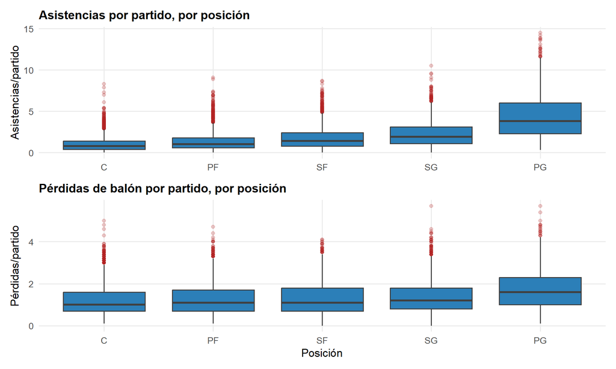

```r
p_ast <- ggplot(df, aes(x = factor(posicion, levels = orden_pos_ast), y = asistencias_pp)) +
  geom_boxplot(fill = col_punto, color = "grey25", outlier.color = col_outlier,
               outlier.alpha = 0.25, na.rm = TRUE) +
  labs(title = "Asistencias por partido, por posición", x = NULL, y = "Asistencias/partido") +
  tema_biv

p_tov <- ggplot(df, aes(x = factor(posicion, levels = orden_pos_ast), y = perdidas_pp)) +
  geom_boxplot(fill = col_punto, color = "grey25", outlier.color = col_outlier,
               outlier.alpha = 0.25, na.rm = TRUE) +
  labs(title = "Pérdidas de balón por partido, por posición", x = "Posición", y = "Pérdidas/partido") +
  tema_biv

p_ast / p_tov
```

```r
cor_por_posicion %>%
  kable(
    digits = c(0, 3),
    col.names = c("Posición", "r (asistencias vs. pérdidas), dentro de la posición"),
    caption = "Correlación asistencias-pérdidas calculada por separado en cada posición"
  ) %>%
  kable_styling(bootstrap_options = c("striped", "condensed"), full_width = FALSE)
```

Correlación asistencias-pérdidas calculada por separado en cada posición

| Posición | r (asistencias vs. pérdidas), dentro de la posición |
| --- | --- |
| C | 0.714 |
| PF | 0.785 |
| SF | 0.827 |
| SG | 0.843 |
| PG | 0.868 |

**Interpretación:** la razón mediana de asistencias por cada pérdida (AST/TOV) aumenta de forma monótona desde los pívots (0.75) hasta los bases (2.44), un incremento de más de tres veces, visible en que ambos boxplots —asistencias y pérdidas por partido— ascienden en el mismo orden de posiciones. Esta diferencia entre posiciones no debe interpretarse como una diferencia de calidad: es la consecuencia mecánica de que un base mantiene el balón en las manos durante una proporción mucho mayor de las posesiones del equipo. La pregunta relevante es si la relación se mantiene dentro de una misma posición, y al calcular la correlación entre asistencias y pérdidas por separado en cada una (tabla anterior), el resultado sigue siendo positivo y de magnitud considerable en las cinco posiciones (entre r = 0.71 y r = 0.87): incluso comparando exclusivamente bases entre sí, un mayor número de asistencias se asocia con más pérdidas. La comparación correcta para evaluar el manejo de balón de un jugador es, entonces, contra sus pares de la misma posición y no contra el conjunto completo del dataset, ya que la diferencia entre posiciones no aporta información sobre la calidad individual, mientras que la diferencia dentro de una posición sí lo hace.

## 1.5 4. Porcentaje de intentos de triple vs. temporada

Esta relación examina la proporción de intentos de tiro que corresponden a triples (`porc_intentos_triple`) a lo largo de las temporadas (`temporada`). Un triple es un lanzamiento realizado desde detrás de una línea marcada en la cancha, ubicada más lejos del aro, que otorga 3 puntos en lugar de los 2 que otorga un lanzamiento convencional. En vez de correlacionar dos estadísticas de un mismo jugador, cruzar el año con el perfil de lanzamiento del conjunto de la liga permite observar un cambio estructural en la forma de jugar baloncesto, conocido como la transición hacia el juego basado en el triple: progresivamente, más equipos determinaron que el punto adicional compensaba la menor precisión del lanzamiento. El interés de esta relación está en identificar el momento en que ese cambio se aceleró, más que en un único coeficiente agregado.

```r
byyear <- df %>%
  group_by(temporada) %>%
  summarise(media_3pa = mean(porc_intentos_triple, na.rm = TRUE), .groups = "drop") %>%
  arrange(temporada) %>%
  mutate(salto = media_3pa - lag(media_3pa))

anio_quiebre <- byyear$temporada[which.max(byyear$salto)]
r_3pa_temporada <- cor(df$porc_intentos_triple, df$temporada, use = "pairwise.complete.obs")

# Agrupar las 41 temporadas en 5 eras para poder comparar con boxplots
df <- df %>%
  mutate(
    era = cut(
      temporada,
      breaks = c(1981, 1989, 1999, 2009, 2014, 2022),
      labels = c("1982-89", "1990-99", "2000-09", "2010-14", "2015-22")
    )
  )
```

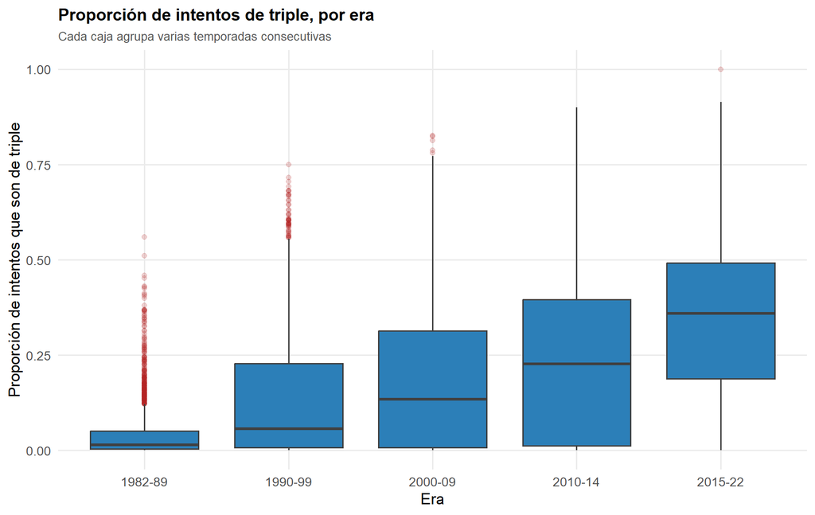

```r
ggplot(df, aes(x = era, y = porc_intentos_triple)) +
  geom_boxplot(fill = col_punto, color = "grey25", outlier.color = col_outlier,
               outlier.alpha = 0.2, na.rm = TRUE) +
  labs(
    title = "Proporción de intentos de triple, por era",
    subtitle = "Cada caja agrupa varias temporadas consecutivas",
    x = "Era", y = "Proporción de intentos que son de triple"
  ) +
  tema_biv
```

```r
byyear %>%
  filter(temporada %in% c(1982, 1995, 2005, 2014, 2018, 2022)) %>%
  select(temporada, media_3pa) %>%
  kable(
    digits = c(0, 3),
    col.names = c("Temporada", "Proporción media de intentos de triple"),
    caption = "Referencia rápida: el triple pasó de ser un recurso marginal a casi 4 de cada 10 intentos"
  ) %>%
  kable_styling(bootstrap_options = c("striped", "condensed"), full_width = FALSE)
```

Referencia rápida: el triple pasó de ser un recurso marginal a casi 4 de cada 10 intentos

| Temporada | Proporción media de intentos de triple |
| --- | --- |
| 1982 | 0.027 |
| 1995 | 0.165 |
| 2005 | 0.172 |
| 2014 | 0.267 |
| 2018 | 0.345 |
| 2022 | 0.397 |

## 1.6 5. Rebote (TRB%) vs. creación de juego (AST%): un trade-off posicional

Esta relación contrasta el porcentaje de rebotes disponibles capturados (`porc_rebotes_tot_disp`, TRB%) con el porcentaje de asistencias del equipo (`porc_asistencias_equipo`, AST%). Un rebote es la acción de capturar el balón después de un lanzamiento fallado, propio o del rival, lo que le otorga a un equipo una nueva oportunidad de atacar o evita que la tenga el rival; “creación de juego” es otra forma de referirse al reparto de asistencias, es decir, a qué tanto un jugador organiza el ataque para que anoten sus compañeros en lugar de anotar él mismo. El análisis univariado ya señalaba que `porc_rebotes_tot_disp` y `porc_asistencias_equipo` cargan con signos opuestos sobre el mismo componente principal (PC2: 0.89 y -0.64); esta sección hace explícita esa oposición como relación bivariada directa.

```r
r_trb_ast <- cor(df$porc_rebotes_tot_disp, df$porc_asistencias_equipo, use = "pairwise.complete.obs")
q_trb75 <- quantile(df$porc_rebotes_tot_disp, 0.75, na.rm = TRUE)
q_ast75 <- quantile(df$porc_asistencias_equipo, 0.75, na.rm = TRUE)
```

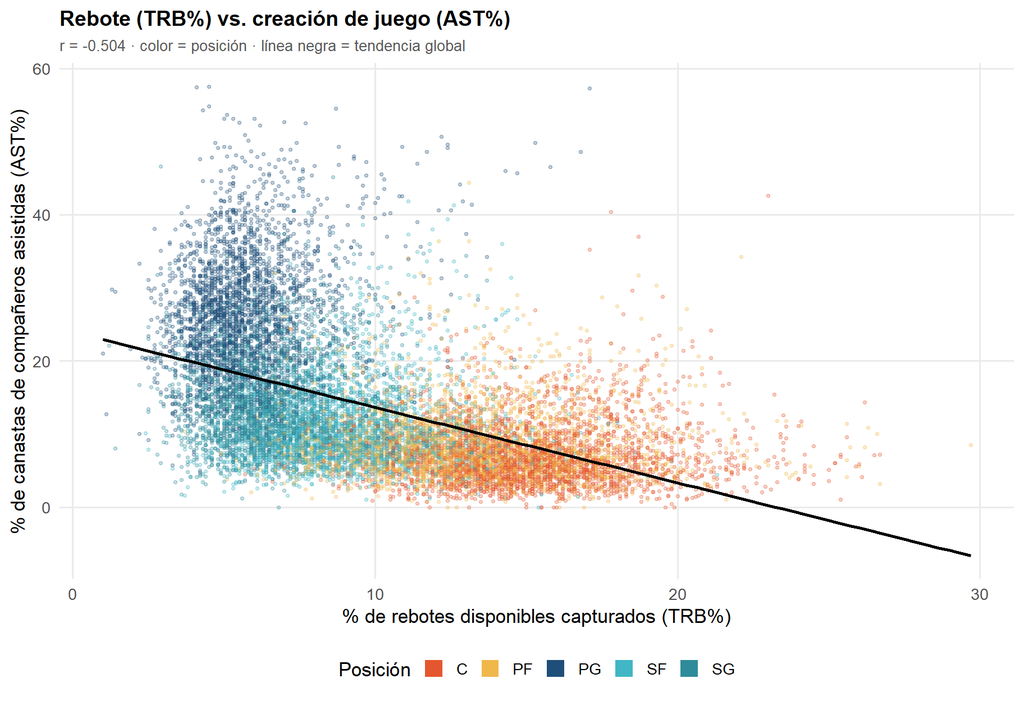

```r
ggplot(df, aes(x = porc_rebotes_tot_disp, y = porc_asistencias_equipo, color = posicion)) +
  geom_point(alpha = 0.25, size = 0.8, na.rm = TRUE) +
  geom_smooth(aes(group = 1), method = "lm", se = FALSE, color = "black", linewidth = 1, na.rm = TRUE) +
  scale_color_manual(values = paleta_posicion) +
  guides(color = guide_legend(title = "Posición", override.aes = list(shape = 15, size = 5, alpha = 1))) +
  labs(
    title = "Rebote (TRB%) vs. creación de juego (AST%)",
    subtitle = paste0("r = ", round(r_trb_ast, 3), " · color = posición · línea negra = tendencia global"),
    x = "% de rebotes disponibles capturados (TRB%)",
    y = "% de canastas de compañeros asistidas (AST%)"
  ) +
  tema_biv
```

```r
df %>%
  filter(porc_rebotes_tot_disp > q_trb75, porc_asistencias_equipo > q_ast75) %>%
  slice_max(valor_sobre_reemplazo, n = 5) %>%
  select(jugador, temporada, posicion, porc_rebotes_tot_disp, porc_asistencias_equipo, valor_sobre_reemplazo) %>%
  kable(
    digits = c(0, 0, 0, 1, 1, 1),
    col.names = c("Jugador", "Temporada", "Posición", "TRB% (rebotes capturados)", "AST% (asistencias repartidas)", "VORP (valor total aportado)"),
    caption = "Arquetipos híbridos: TRB% y AST% simultáneamente en el 25% más alto"
  ) %>%
  kable_styling(bootstrap_options = c("striped", "condensed"), full_width = FALSE)
```

Arquetipos híbridos: TRB% y AST% simultáneamente en el 25% más alto

| Jugador | Temporada | Posición | TRB% (rebotes capturados) | AST% (asistencias repartidas) | VORP (valor total aportado) |
| --- | --- | --- | --- | --- | --- |
| David Robinson | 1994 | C | 14.8 | 21.6 | 11.4 |
| Kevin Garnett | 2004 | PF | 20.1 | 24.4 | 10.0 |
| Nikola Jokić | 2022 | C | 23.0 | 42.6 | 9.8 |
| Russell Westbrook | 2017 | PG | 17.1 | 57.3 | 9.3 |
| Kevin Garnett | 2005 | PF | 20.3 | 27.1 | 9.1 |

**Interpretación:** la relación es negativa y de magnitud moderada (r = -0.504), y el color por posición explica por qué: los pívots dominan la esquina de TRB% alto y AST% bajo, mientras que los bases dominan la esquina opuesta. Nada en la fórmula de ninguna de las dos variables obliga a esta oposición —a diferencia de las identidades algebraicas detectadas en el análisis univariado—, por lo que la correlación negativa constituye un patrón real del juego y no un artefacto de cálculo. Este patrón corresponde a la especialización posicional clásica del baloncesto: el jugador que se ubica cerca del aro captura más rebotes porque ahí termina la mayoría de los lanzamientos fallados, mientras que el jugador que organiza el ataque reparte más asistencias porque tiene el balón en las manos con mayor frecuencia. Los pocos casos que aparecen en la esquina superior derecha —Nikola Jokić, Russell Westbrook o Kevin Garnett en algunas de sus temporadas— resultan estadísticamente atípicos precisamente porque combinan dos roles que el juego separa de forma sistemática, y esa rareza estadística es la base de por qué este tipo de jugadores suele describirse como generacional: no sobresalen en una sola dimensión, sino que alteran la estructura misma del rol que ocupan.

## 1.7 6. Protagonismo (USG%) vs. producción (puntos por partido)

Esta relación complementa la primera: contrasta el Porcentaje de Uso (`porc_uso_jugador`, USG%) con los puntos por partido (`puntos_pp`) para examinar si es posible anotar en volumen sin ser el protagonista ofensivo del equipo, es decir, sin necesitar un uso ofensivo alto.

```r
r_usg_pts <- cor(df$porc_uso_jugador, df$puntos_pp, use = "pairwise.complete.obs")
```

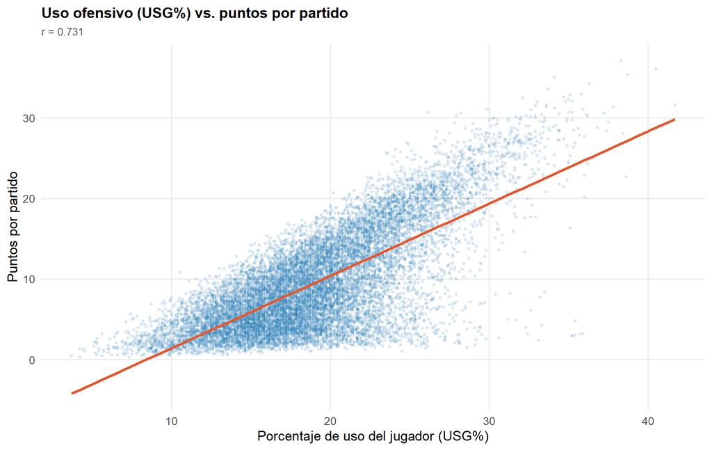

```r
ggplot(df, aes(x = porc_uso_jugador, y = puntos_pp)) +
  geom_point(alpha = 0.12, color = col_punto, size = 0.8, na.rm = TRUE) +
  geom_smooth(method = "lm", se = FALSE, color = col_ajuste, na.rm = TRUE) +
  labs(
    title = "Uso ofensivo (USG%) vs. puntos por partido",
    subtitle = paste0("r = ", round(r_usg_pts, 3)),
    x = "Porcentaje de uso del jugador (USG%)",
    y = "Puntos por partido"
  ) +
  tema_biv
```

```r
df %>%
  filter(
    porc_uso_jugador < quantile(porc_uso_jugador, 0.40, na.rm = TRUE),
    puntos_pp > quantile(puntos_pp, 0.75, na.rm = TRUE)
  ) %>%
  slice_max(puntos_pp, n = 5) %>%
  select(jugador, temporada, porc_uso_jugador, puntos_pp, porc_tiro_verdadero) %>%
  kable(
    digits = c(0, 0, 1, 1, 3),
    col.names = c("Jugador", "Temporada", "USG% (uso ofensivo)", "Puntos por partido", "TS% (eficiencia de tiro)"),
    caption = "Anotan mucho sin ser el protagonista ofensivo: bajo USG%, muchos puntos"
  ) %>%
  kable_styling(bootstrap_options = c("striped", "condensed"), full_width = FALSE)
```

Anotan mucho sin ser el protagonista ofensivo: bajo USG%, muchos puntos

| Jugador | Temporada | USG% (uso ofensivo) | Puntos por partido | TS% (eficiencia de tiro) |
| --- | --- | --- | --- | --- |
| Dan Majerle | 1993 | 17.3 | 16.9 | 0.573 |
| Harrison Barnes | 2021 | 17.2 | 16.1 | 0.626 |
| Michael Cage | 1987 | 17.1 | 15.7 | 0.579 |
| Danny Ainge | 1988 | 17.3 | 15.7 | 0.598 |
| Rudy Gobert | 2022 | 16.9 | 15.6 | 0.732 |

**Interpretación:** la correlación es fuerte (r = 0.731) y más alta que la observada entre USG% y TS%, en la dirección esperada: el volumen de tiro y el volumen de anotación comparten la misma raíz. No obstante, como en la primera relación, lo más informativo está fuera de la nube principal: existe un grupo de jugadores con USG% en el 40% más bajo del dataset que, aun así, anota en el 25% más alto. Ese grupo —Rudy Gobert anotando principalmente de cerca del aro con un TS% de 0.73, o tiradores como Dan Majerle y Harrison Barnes— representa un arquetipo de valor distinto al de la primera relación: no llevan el peso de crear su propio lanzamiento, pero convierten con alta eficiencia casi todo lo que reciben. Para la construcción de una plantilla, esta distinción equivale a la diferencia entre pagarle a un jugador por generar ofensiva y pagarle por capitalizar la ofensiva que otros generan; son dos habilidades distintas que `puntos_pp` por sí solo no distingue, pero que emergen con claridad al cruzarla con `porc_uso_jugador`.

## 1.8 7. Minutos totales vs. valor sobre el reemplazo (VORP)

Esta relación contrasta los minutos totales jugados en la temporada (`minutos_totales`) con el Valor Sobre el Jugador de Reemplazo (`valor_sobre_reemplazo`, VORP), que estima cuánto valor aportó un jugador durante toda la temporada en comparación con el mínimo que cualquier equipo podría conseguir gratuitamente en el mercado —un “jugador de reemplazo”—; a diferencia del PER, el VORP es un acumulado de toda la temporada y no una tasa por minuto, por lo que también premia jugar muchos minutos, no solo jugar bien. El análisis univariado ya señalaba a `minutos_totales` como control obligatorio para cualquier variable acumulada, y esta sección hace explícita esa relación con la variable de valor más agregada del panel.

```r
r_min_vorp <- cor(df$minutos_totales, df$valor_sobre_reemplazo, use = "pairwise.complete.obs")

tabla_decil <- df %>%
  mutate(decil_minutos = ntile(minutos_totales, 10)) %>%
  group_by(decil_minutos) %>%
  summarise(
    minutos_prom = mean(minutos_totales, na.rm = TRUE),
    vorp_prom = mean(valor_sobre_reemplazo, na.rm = TRUE),
    .groups = "drop"
  )
```

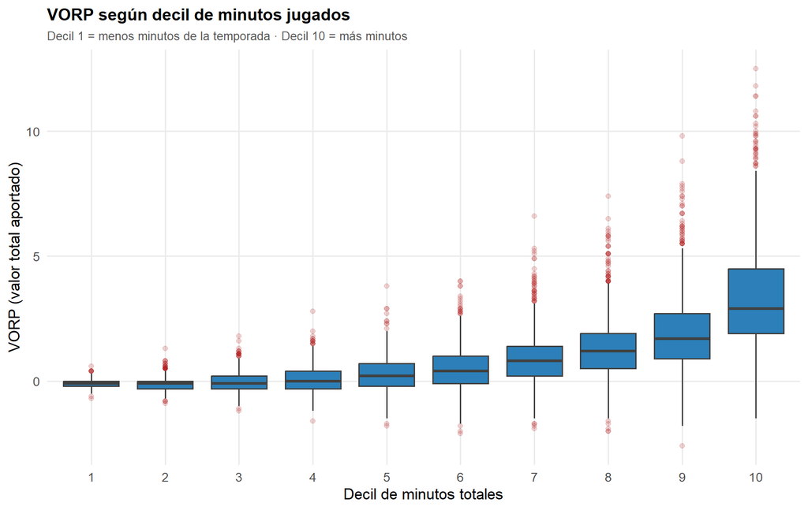

```r
df %>%
  mutate(decil_minutos = ntile(minutos_totales, 10)) %>%
  ggplot(aes(x = factor(decil_minutos), y = valor_sobre_reemplazo)) +
  geom_boxplot(fill = col_punto, color = "grey25", outlier.color = col_outlier,
               outlier.alpha = 0.2, na.rm = TRUE) +
  labs(
    title = "VORP según decil de minutos jugados",
    subtitle = "Decil 1 = menos minutos de la temporada · Decil 10 = más minutos",
    x = "Decil de minutos totales", y = "VORP (valor total aportado)"
  ) +
  tema_biv
```

```r
tabla_decil %>%
  kable(
    digits = c(0, 0, 2),
    col.names = c("Decil de minutos (1 = menos juega, 10 = más juega)", "Minutos promedio", "VORP promedio (valor total aportado)"),
    caption = "VORP promedio por decil de minutos jugados"
  ) %>%
  kable_styling(bootstrap_options = c("striped", "condensed"), full_width = FALSE)
```

VORP promedio por decil de minutos jugados

| Decil de minutos (1 = menos juega, 10 = más juega) | Minutos promedio | VORP promedio (valor total aportado) |
| --- | --- | --- |
| 1 | 182 | -0.09 |
| 2 | 402 | -0.11 |
| 3 | 681 | -0.07 |
| 4 | 968 | 0.05 |
| 5 | 1260 | 0.26 |
| 6 | 1552 | 0.47 |
| 7 | 1838 | 0.85 |
| 8 | 2143 | 1.27 |
| 9 | 2482 | 1.87 |
| 10 | 2920 | 3.30 |

## 1.9 8. Uso ofensivo (USG%) vs. pérdidas normalizadas

Esta relación pone a prueba una intuición común: que manejar más el balón —un Porcentaje de Uso (USG%) más alto— debería producir más pérdidas por jugada. Se examina con la versión normalizada de las pérdidas (`porc_perdidas_jugada`, pérdidas por cada 100 jugadas individuales) en lugar del conteo bruto por partido, para aislar el riesgo de pérdida por jugada del efecto puramente mecánico de jugar más minutos.

```r
r_usg_tov <- cor(df$porc_uso_jugador, df$porc_perdidas_jugada, use = "pairwise.complete.obs")
```

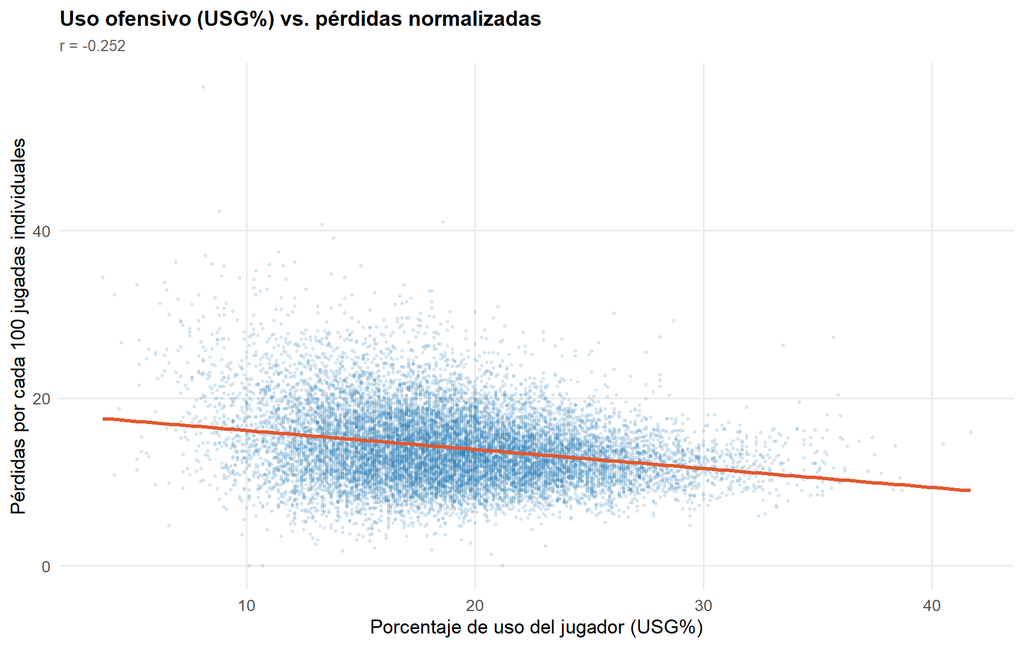

```r
ggplot(df, aes(x = porc_uso_jugador, y = porc_perdidas_jugada)) +
  geom_point(alpha = 0.12, color = col_punto, size = 0.7, na.rm = TRUE) +
  geom_smooth(method = "lm", se = FALSE, color = col_ajuste, na.rm = TRUE) +
  labs(
    title = "Uso ofensivo (USG%) vs. pérdidas normalizadas",
    subtitle = paste0("r = ", round(r_usg_tov, 3)),
    x = "Porcentaje de uso del jugador (USG%)",
    y = "Pérdidas por cada 100 jugadas individuales"
  ) +
  tema_biv
```

**Interpretación:** la correlación resulta negativa (r = -0.252), el signo contrario al que predeciría la intuición de que manejar más el balón implica perderlo con más frecuencia: a medida que sube el USG%, la tasa de pérdidas por jugada tiende a bajar levemente en lugar de subir. El resultado se explica al revisar la definición exacta de la variable: `porc_perdidas_jugada` normaliza las pérdidas por el número de jugadas individuales en las que participa el jugador, no solo por sus minutos jugados, y un jugador con USG% alto suele ser también un manejador de balón más hábil, dado que llegar a ese rol exige superar un filtro de selección —a un base con mal manejo de balón difícilmente se le asigna un USG% alto durante muchas temporadas—. Este hallazgo no contradice lo observado en la relación 3, donde sí se confirma que los bases pierden más balones por partido que los pívots: son dos preguntas distintas, pérdidas absolutas asociadas al rol (relación 3) frente a riesgo de pérdida por jugada individual una vez que el jugador ya tiene el balón (esta relación). La lección metodológica de fondo es que, antes de interpretar el signo de una correlación, es necesario revisar cómo está definida exactamente cada variable involucrada.

## 1.10 9. Porcentaje de victorias del equipo vs. impacto defensivo individual (DBPM)

Esta relación contrasta el porcentaje de victorias del equipo (`porc_victorias_equipo`) con el Box Plus/Minus defensivo (`masmenos_defensivo`, DBPM), que estima cuántos puntos por cada 100 posesiones aporta o resta un jugador únicamente en la faceta defensiva del juego, en comparación con un jugador promedio de la liga. Las métricas defensivas individuales se cuentan entre las menos fiables de la estadística de baloncesto porque dependen en buena medida del sistema táctico del equipo; esta relación sirve como control de validez para comprobar si los buenos defensores solo aparecen en equipos ganadores, o si el dato individual sobrevive incluso en equipos con mal desempeño colectivo.

```r
r_win_dbpm <- cor(df$porc_victorias_equipo, df$masmenos_defensivo, use = "pairwise.complete.obs")
q_dbpm85 <- quantile(df$masmenos_defensivo, 0.85, na.rm = TRUE)
q_win25 <- quantile(df$porc_victorias_equipo, 0.25, na.rm = TRUE)
```

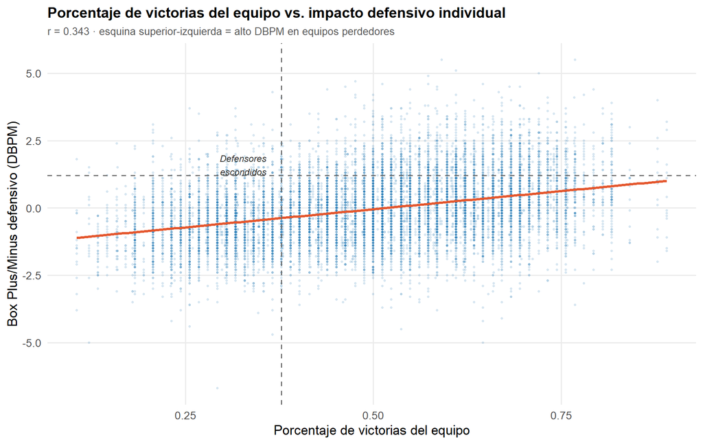

```r
ggplot(df, aes(x = porc_victorias_equipo, y = masmenos_defensivo)) +
  geom_point(alpha = 0.12, color = col_punto, size = 0.7, na.rm = TRUE) +
  geom_smooth(method = "lm", se = FALSE, color = col_ajuste, na.rm = TRUE) +
  geom_hline(yintercept = q_dbpm85, linetype = "dashed", color = "grey45") +
  geom_vline(xintercept = q_win25, linetype = "dashed", color = "grey45") +
  annotate(
    "text", x = q_win25 - 0.02, y = q_dbpm85 + 0.4,
    label = "Defensores\nescondidos", hjust = 1, size = 3.2,
    fontface = "italic", color = "grey20"
  ) +
  labs(
    title = "Porcentaje de victorias del equipo vs. impacto defensivo individual",
    subtitle = paste0("r = ", round(r_win_dbpm, 3), " · esquina superior-izquierda = alto DBPM en equipos perdedores"),
    x = "Porcentaje de victorias del equipo", y = "Box Plus/Minus defensivo (DBPM)"
  ) +
  tema_biv
```

```r
df %>%
  filter(masmenos_defensivo > q_dbpm85, porc_victorias_equipo < q_win25) %>%
  slice_max(masmenos_defensivo, n = 5) %>%
  select(jugador, temporada, equipo, masmenos_defensivo, porc_victorias_equipo) %>%
  kable(
    digits = c(0, 0, 0, 1, 3),
    col.names = c("Jugador", "Temporada", "Equipo", "DBPM (impacto defensivo)", "% victorias del equipo"),
    caption = "\"Defensores escondidos\": DBPM alto en equipos con pocas victorias"
  ) %>%
  kable_styling(bootstrap_options = c("striped", "condensed"), full_width = FALSE)
```

“Defensores escondidos”: DBPM alto en equipos con pocas victorias

| Jugador | Temporada | Equipo | DBPM (impacto defensivo) | % victorias del equipo |
| --- | --- | --- | --- | --- |
| Mark Eaton | 1983 | UTA | 4.3 | 0.366 |
| Eric Murdock | 1997 | DEN | 3.7 | 0.256 |
| Andrei Kirilenko | 2005 | UTA | 3.7 | 0.317 |
| Kyle Lowry | 2007 | MEM | 3.5 | 0.268 |
| Quinn Buckner | 1986 | IND | 3.4 | 0.317 |

**Interpretación:** la correlación es positiva pero de magnitud moderada (r = 0.343), sensiblemente más débil que la observada entre `porc_victorias_equipo` y `margen_victoria` (r > 0.96), identificada en el análisis univariado como la expresión de la expectativa pitagórica del baloncesto. Existe, además, un grupo identificable en la esquina superior izquierda del gráfico: jugadores con DBPM en el 15% más alto del dataset que, sin embargo, juegan en equipos ubicados en el 25% con menos victorias. Una correlación moderada —ni cercana a cero ni extremadamente alta— es justamente lo que cabría esperar si el DBPM mide algo real del jugador además del contexto de su equipo: si esta métrica fuera resultado exclusivo del sistema táctico, no debería existir un grupo estable de jugadores con DBPM alto en equipos de bajo desempeño, como Mark Eaton, un joven Kyle Lowry o Andrei Kirilenko. Estos casos muestran que la habilidad defensiva individual puede sostenerse incluso sin un equipo ganador alrededor, lo que constituye evidencia de que el DBPM conserva señal aprovechable para identificar a un defensor infravalorado en un equipo con mal récord, aunque siempre debe interpretarse junto con el contexto de equipo y nunca de forma aislada.

## 1.11 10. Años de experiencia vs. eficiencia, controlando por edad de entrada

Un jugador universitario que ingresa a la liga a los 22 años y otro que ingresa a los 19 no son comparables en su primera temporada, porque “experiencia” y “edad” están correlacionadas pero no son lo mismo. Esta relación aísla ese efecto construyendo dos variables derivadas que no existen directamente en `nbaFINAL.csv`: los años de experiencia en la liga y la edad de entrada de cada jugador.

```r
entrada <- df %>%
  group_by(jugador) %>%
  slice_min(temporada, n = 1, with_ties = FALSE) %>%
  ungroup() %>%
  select(jugador, edad_entrada = edad)

df_exp <- df %>%
  left_join(entrada, by = "jugador") %>%
  group_by(jugador) %>%
  mutate(experiencia = temporada - min(temporada)) %>%
  ungroup() %>%
  mutate(
    categoria_entrada = case_when(
      edad_entrada <= 19 ~ "<=19",
      edad_entrada <= 21 ~ "20-21",
      edad_entrada <= 23 ~ "22-23",
      TRUE ~ "24+"
    ),
    categoria_entrada = factor(categoria_entrada, levels = c("<=19", "20-21", "22-23", "24+"))
  )
```

```r
df_exp %>%
  distinct(jugador, categoria_entrada) %>%
  count(categoria_entrada) %>%
  kable(
    col.names = c("Edad de entrada a la liga", "Número de jugadores"),
    caption = "Tamaño de cada grupo de edad de entrada"
  ) %>%
  kable_styling(bootstrap_options = c("striped", "condensed"), full_width = FALSE)
```

Tamaño de cada grupo de edad de entrada

| Edad de entrada a la liga | Número de jugadores |
| --- | --- |
| <=19 | 132 |
| 20-21 | 515 |
| 22-23 | 1245 |
| 24+ | 803 |

```r
df_exp %>%
  filter(experiencia <= 5) %>%
  group_by(categoria_entrada, experiencia) %>%
  summarise(PER_promedio = mean(indice_eficiencia, na.rm = TRUE), .groups = "drop") %>%
  pivot_wider(names_from = categoria_entrada, values_from = PER_promedio) %>%
  kable(
    digits = 2,
    caption = "PER promedio según años de experiencia, por edad de entrada a la liga"
  ) %>%
  kable_styling(bootstrap_options = c("striped", "condensed"), full_width = FALSE)
```

PER promedio según años de experiencia, por edad de entrada a la liga

| experiencia | <=19 | 20-21 | 22-23 | 24+ |
| --- | --- | --- | --- | --- |
| 0 | 12.05 | 12.33 | 11.38 | 11.81 |
| 1 | 13.57 | 14.31 | 12.82 | 12.99 |
| 2 | 14.91 | 15.40 | 13.61 | 13.51 |
| 3 | 16.95 | 16.08 | 14.02 | 13.41 |
| 4 | 17.19 | 16.61 | 14.07 | 13.38 |
| 5 | 17.83 | 16.63 | 13.99 | 13.11 |

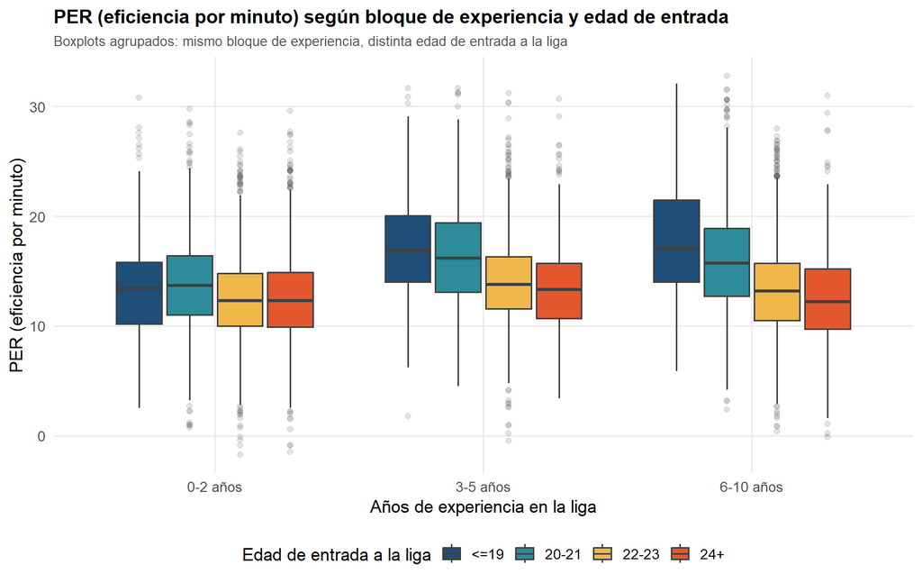

```r
df_exp %>%
  filter(experiencia <= 10) %>%
  mutate(
    bloque_experiencia = cut(
      experiencia,
      breaks = c(-1, 2, 5, 10),
      labels = c("0-2 años", "3-5 años", "6-10 años")
    )
  ) %>%
  ggplot(aes(x = bloque_experiencia, y = indice_eficiencia, fill = categoria_entrada)) +
  geom_boxplot(color = "grey25", outlier.alpha = 0.15, na.rm = TRUE) +
  scale_fill_manual(values = paleta_entrada, name = "Edad de entrada a la liga") +
  labs(
    title = "PER (eficiencia por minuto) según bloque de experiencia y edad de entrada",
    subtitle = "Boxplots agrupados: mismo bloque de experiencia, distinta edad de entrada a la liga",
    x = "Años de experiencia en la liga", y = "PER (eficiencia por minuto)"
  ) +
  tema_biv
```

## 1.12 11. Anotación (puntos por partido) vs. creación de juego (asistencias por partido), por posición

Esta relación contrasta los puntos por partido (`puntos_pp`) con las asistencias por partido (`asistencias_pp`). La gestión de las posesiones sugiere un compromiso lógico entre ambas variables: si un jugador lanza a canasta, no puede asistir a un compañero en esa misma jugada, por lo que sería razonable esperar que los perfiles de alta anotación registren pocas asistencias, y viceversa, separando a los finalizadores de los distribuidores de juego. Se colorea por `posicion` para examinar si ese supuesto compromiso se cumple dentro de cada rol o si, como en la relación 5, existe un grupo que rompe la regla.

```r
r_pts_ast <- cor(df$puntos_pp, df$asistencias_pp, use = "pairwise.complete.obs")

tabla_pts_ast <- df %>%
  group_by(posicion) %>%
  summarise(
    puntos_mediana = median(puntos_pp, na.rm = TRUE),
    asistencias_mediana = median(asistencias_pp, na.rm = TRUE),
    .groups = "drop"
  ) %>%
  arrange(asistencias_mediana)

orden_pos_ast2 <- tabla_pts_ast$posicion

q_pts75 <- quantile(df$puntos_pp, 0.75, na.rm = TRUE)
q_ast75 <- quantile(df$asistencias_pp, 0.75, na.rm = TRUE)
```

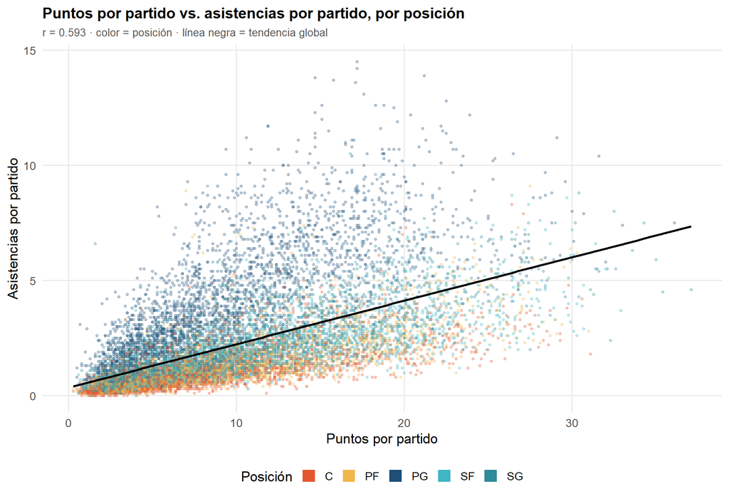

```r
ggplot(df, aes(x = puntos_pp, y = asistencias_pp, color = posicion)) +
  geom_point(alpha = 0.25, size = 0.8, na.rm = TRUE) +
  geom_smooth(aes(group = 1), method = "lm", se = FALSE, color = "black", linewidth = 1, na.rm = TRUE) +
  scale_color_manual(values = paleta_posicion) +
  guides(color = guide_legend(title = "Posición", override.aes = list(shape = 15, size = 5, alpha = 1))) +
  labs(
    title = "Puntos por partido vs. asistencias por partido, por posición",
    subtitle = paste0("r = ", round(r_pts_ast, 3), " · color = posición · línea negra = tendencia global"),
    x = "Puntos por partido", y = "Asistencias por partido"
  ) +
  tema_biv
```

```r
tabla_pts_ast %>%
  kable(
    digits = c(0, 1, 1),
    col.names = c("Posición", "Puntos/partido (mediana)", "Asistencias/partido (mediana)"),
    caption = "Puntos y asistencias por partido, por posición (ordenado de menor a mayor asistencias)"
  ) %>%
  kable_styling(bootstrap_options = c("striped", "condensed"), full_width = FALSE)
```

Puntos y asistencias por partido, por posición (ordenado de menor a mayor asistencias)

| Posición | Puntos/partido (mediana) | Asistencias/partido (mediana) |
| --- | --- | --- |
| C | 6.4 | 0.8 |
| PF | 7.5 | 1.0 |
| SF | 8.6 | 1.4 |
| SG | 9.1 | 1.9 |
| PG | 8.4 | 3.8 |

```r
df %>%
  filter(puntos_pp > q_pts75, asistencias_pp > q_ast75) %>%
  slice_max(valor_sobre_reemplazo, n = 6) %>%
  select(jugador, temporada, posicion, puntos_pp, asistencias_pp, valor_sobre_reemplazo) %>%
  kable(
    digits = c(0, 0, 0, 1, 1, 1),
    col.names = c("Jugador", "Temporada", "Posición", "Puntos/partido", "Asistencias/partido", "VORP (valor total aportado)"),
    caption = "Anotan y asisten a la vez: puntos y asistencias simultáneamente en el 25% más alto"
  ) %>%
  kable_styling(bootstrap_options = c("striped", "condensed"), full_width = FALSE)
```

Anotan y asisten a la vez: puntos y asistencias simultáneamente en el 25% más alto

| Jugador | Temporada | Posición | Puntos/partido | Asistencias/partido | VORP (valor total aportado) |
| --- | --- | --- | --- | --- | --- |
| Michael Jordan | 1988 | SG | 35.0 | 5.9 | 12.5 |
| LeBron James | 2009 | SF | 28.4 | 7.2 | 11.8 |
| Michael Jordan | 1989 | SG | 32.5 | 8.0 | 11.4 |
| David Robinson | 1994 | C | 29.8 | 4.8 | 11.4 |
| Michael Jordan | 1991 | SG | 31.5 | 5.5 | 10.8 |
| Michael Jordan | 1987 | SG | 37.1 | 4.6 | 10.6 |
| Michael Jordan | 1990 | SG | 33.6 | 6.3 | 10.6 |

**Interpretación:** la correlación es r = 0.593, positiva y de magnitud moderada, el signo contrario al que predeciría un compromiso estricto entre anotar y asistir. La tabla por posición explica por qué: los bases (PG) tienen una mediana de asistencias muy por encima del resto (3.8, frente a 0.8-1.9 en las demás posiciones), pero sus puntos por partido no son los más bajos, sino que se ubican en el mismo rango que los de aleros y ala-pívots. Son los bases quienes empujan la relación hacia arriba al combinar buen volumen de anotación con muchas asistencias, y no un reparto estricto entre anotar o asistir dentro de cada posición. El grupo que aparece simultáneamente en el 25% más alto de ambas variables (tabla anterior) no está dominado por bases, como sugeriría la intuición de que el base es quien reparte, sino por escoltas y aleros con el balón en las manos — Michael Jordan y LeBron James concentran varias de las mejores temporadas de esta tabla—, jugadores que funcionan como el principal generador ofensivo de su equipo sin ocupar formalmente la posición de base. Para la construcción de una plantilla, esto confirma que anotador y creador de juego no son roles excluyentes que dependan de la posición asignada, sino habilidades que algunos jugadores de élite combinan a la vez, y que el dato de posición por sí solo no captura.

# 2 Conclusiones del análisis bivariado